# Estimate tree height and crown dimensions

Author

Vincyane Badouard

Published

February 20, 2025

Arbres communs avec ceux de Claudia -> prendre l’estimation de Claudia de la hauteur de l’arbre et du rayon de la couronne  
Autres arbres :  
- **TreeHeight** : par une allométrie issue des données de Claudia et FTH  
- **CrownDiameter** : par une allométrie CC (à faire en dernier)

Pour tout le monde :  
- **CrownHeight** = TreeHeight * 0.3

**PRENDRE DBHcor** !!!!  
**Sauf pour les multistems : il faut prendre DBH de la 1ère tige**

# Packages

```r
library(tidyverse)
library(data.table)
library(readr)
library(BIOMASS)
```

# Import cleaned inventory data

```r
Understory <- read.csv("~/PhD/Inventories/Data/Understory/Paracou/ALT_Paracou_9ha_Filtred.csv") %>%
  rename(idTree = IdTree) %>% # 28 711
  rename(SubPlot = Subplot)
Adults <- read.csv("~/PhD/Inventories/Data/Adults/Paracou/AdultsP16_filtred.csv") %>%  # 25 ha
  mutate(idTree = as.character(idTree)) %>%
  filter(ScientificName %in% Understory$ScientificName)
```

# Plot H-D data

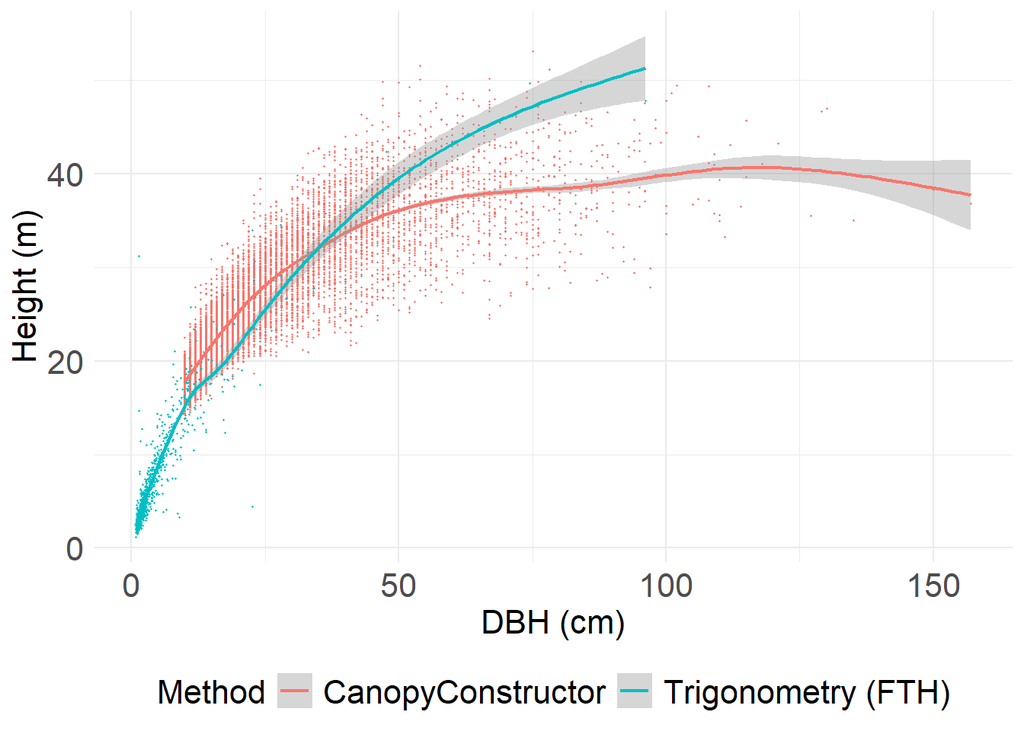

```r
data %>%
  ggplot() +
  aes(x = DBH, y = TreeHeight, colour=HeightHow) +
  geom_point(shape = "circle", size = 0.2) + # , colour = "#440154"
  geom_smooth(span = 0.75, linewidth = 0.8) + # using method = 'gam' and formula 'y ~ s(x, bs = "cs")'
  theme_minimal() +
  labs(x ="DBH (cm)", y = "Height (m)", colour = "Method") +
  theme(axis.title= element_text(size=16), axis.text= element_text(size=16),
        legend.title= element_text(size=16), legend.text= element_text(size=16),
        legend.position="bottom")
```

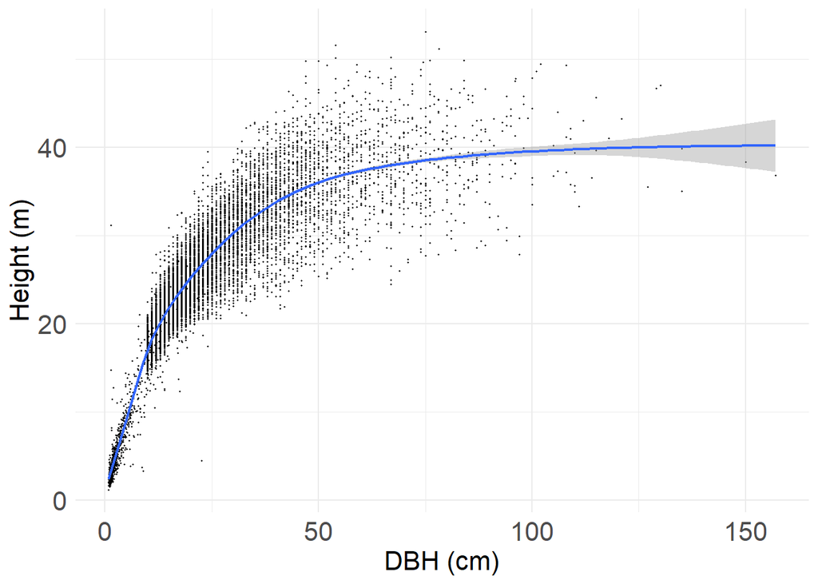

```r
# ggsave("DBH_height_methods.png", path = "D:/Mes Donnees/PhD/Figures/inventory",
#        width = 20, height = 20, units = "cm", dpi=800, bg="white")


data %>%
  ggplot() +
  aes(x = DBH, y = TreeHeight) +
  geom_point(shape = "circle", size = 0.2) + # , colour = "#440154"
  geom_smooth(span = 0.75, linewidth = 0.8) +
  theme_minimal() +
  labs(x ="DBH (cm)", y = "Height (m)") +
  theme(axis.title= element_text(size=16), axis.text= element_text(size=16),
        legend.title= element_text(size=16), legend.text= element_text(size=16))
```

```r
# ggsave("DBH_height_CCandFTH.png", path = "D:/Mes Donnees/PhD/Figures/inventory",
#        width = 20, height = 20, units = "cm", dpi=800, bg="white")
```

# Plot crown dimensions data

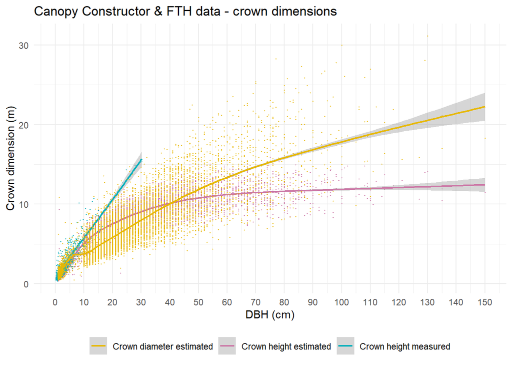

```r
data %>%
  mutate(CrownHeight = TreeHeight*0.3) %>%
  ggplot() +
  aes(x = DBH, y = CrownHeight) +
  # Estimated height
  geom_point(aes(col = "Crown height estimated"), size = 0.2) +
  geom_smooth(span = 0.75, linewidth = 0.8, aes(color = "Crown height estimated")) +
  # Measured height
  geom_point(size = 0.2, aes(TreeHeight - CrownBase, col = "Crown height measured")) +
  geom_smooth(span = 0.75, linewidth = 0.8, aes(TreeHeight - CrownBase, col = "Crown height measured")) +
  # Measured diameter
  geom_point(size = 0.2, aes(y = CrownRadius*2, color = "Crown diameter estimated")) +
  geom_smooth(span = 0.75, linewidth = 0.8, aes(y = CrownRadius*2, color = "Crown diameter estimated")) + # using method = 'gam' and formula 'y ~ s(x, bs = "cs")'

  theme_minimal() +
  scale_color_manual(values = c("Crown height estimated" = "#CC79A7",
                                "Crown height measured" = "#00AFBB",
                                "Crown diameter estimated"= "#E7B800")) +
  labs(title = "Canopy Constructor & FTH data - crown dimensions", x ="DBH (cm)", y = "Crown dimension (m)") +
  scale_x_continuous(limits = c(0, 150), breaks = seq(0, 150, by=10)) +
  theme(legend.position="bottom",
        # axis.title= element_text(size=16), axis.text= element_text(size=16), legend.text= element_text(size=16),
        legend.title= element_blank()
  )
```

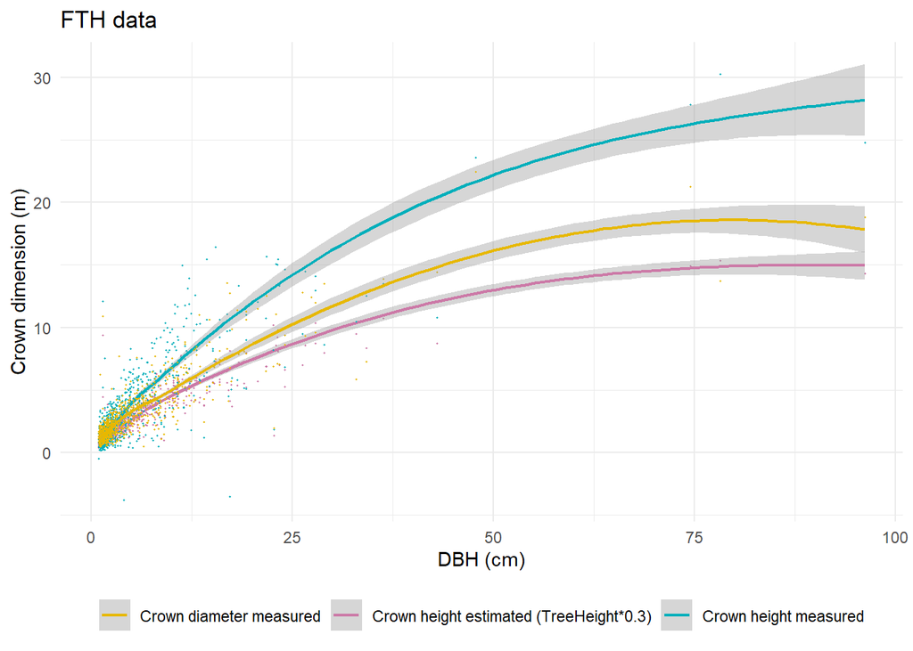

```r
# ggsave("CrownDimensions-FTH_Claudiasdata.png", path= "D:/Mes Donnees/PhD/Figures/inventory", width = 20, height = 15, units = "cm", dpi=800, bg="white")

FTH %>%
  # filter(DBH<=10) %>%
  mutate(CrownHeight = TreeHeight*0.3) %>%
  ggplot() +
  # Estimated height
  aes(x = DBH, y = CrownHeight) +
  geom_point(aes(col = "Crown height estimated (TreeHeight*0.3)"), size = 0.2) +
  geom_smooth(span = 0.75, linewidth = 0.8, aes(col = "Crown height estimated (TreeHeight*0.3)")) +
  # Measured height
  geom_point(aes(y = TreeHeight - CrownBase, col = "Crown height measured"), size = 0.2) +
  geom_smooth(span = 0.75, linewidth = 0.8, aes(y = TreeHeight - CrownBase, col = "Crown height measured")) +
  # Measured diameter
  geom_point(size = 0.2, aes(y = CrownRadius*2, col = "Crown diameter measured")) +
  geom_smooth(span = 0.75, linewidth = 0.8, aes(y = CrownRadius*2, col = "Crown diameter measured")) +

  theme_minimal() +
  scale_color_manual(values = c("Crown height estimated (TreeHeight*0.3)" = "#CC79A7",
                                "Crown height measured" = "#00AFBB",
                                "Crown diameter measured"= "#E7B800")) +
  labs(title = "FTH data", x ="DBH (cm)", y = "Crown dimension (m)") +
  # scale_x_continuous(limits = c(1, 10), breaks = seq(1, 10, by=1)) +
  #   scale_y_continuous(limits = c(1, 13), breaks = seq(1, 13, by=2)) +
  theme(legend.position="bottom",
        # axis.title= element_text(size=16), axis.text= element_text(size=16), legend.text= element_text(size=16),
        legend.title= element_blank()
  )
```